# Trajectory Inference

26.07.2021

## Single Cell RNAseq Analysis Workflow

[figure not shown]

## Trajectory Inference

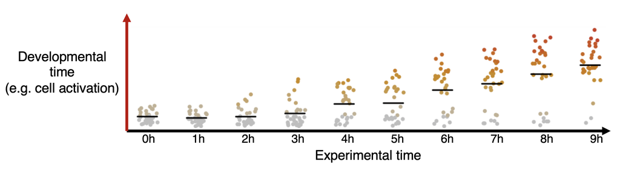

- Cells that differentiate display a continuous spectrum of states
  - Transcriptional program for activation and differentiation
- Individual cells will differentiate in an unsynchronized manner
  - Each cell is a snapshot of differentiation time
- Pseudotime – abstract unit of progress
  - Distance between a cell and the start of the trajectory

## Should you run trajectory inference?

- Are you sure that you have a developmental trajectory?
- Do you have intermediate states?
- Do you believe that you have branching in your trajectory?
- Be aware, any dataset can be forced into a trajectory without any biological meaning!
- First make sure that gene set and dimensionality reduction captures what you expect.

## Trajectory Inference Methods

- Saelens et al. (2019) Nature Biotechnology

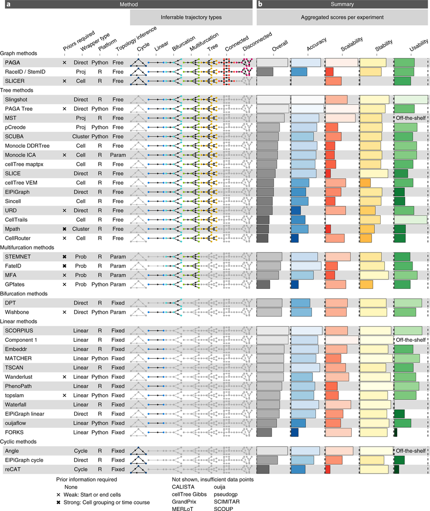

## Which method to use?

[figure not shown]

## Diffusion Maps (in brief)

- It is a NON-LINEAR method of dimensionality reduction.
- The distances between points are measured as probability from going from one to another.
- The data must present connectivity (transitional cells).

## Final Considerations

- In reality, distance in multidimensional space reflects difference in transcriptional landscape, not actual time.
- Necessary to have a continuum of states among your cells (Will not work well with 2 distinct clusters)
- May work with single time-point if ongoing differentiation process (It is better to have multiple experimental time points)
- Be aware, any dataset can be forced into a trajectory without any biological meaning!